# ¿Qué es un ambiente virtual?

Por ejemplo nosotros tenemos un ambiente con matplotlib 3.6 de manera global, con ciertos módulos de numpy y pandas. A esto se le llama que se instalan de forma o general o global, y esto significa que estas librerías quedan a uso compartido para cualquiera que necesite ejecutarlo en la maquina.

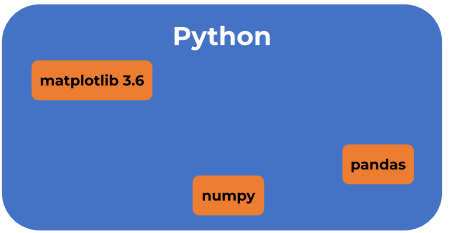

Esto puede generar un poco de conflictos porque si tienes diferentes proyectos o estas con diferentes compañías, microservicios pueden empezar a chocar o tener conflictos entre ellos

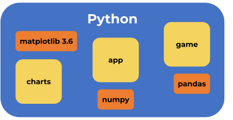

Digamos que para cada proyecto como los que se ven amarillo, necesitas ciertas versiones en especifico de cada librería u otro tipo de librerías o módulos.

Al tener todo de forma compartida, puede empezar a colapsar y a generar errores.

## Ambientes virtuales

Para esta problemática se crearon los ambientes virtuales en Python.

Los ambientes virtuales en Python encapsulan cada uno de los módulos y lo atan a cada proyecto, y no lo dejan en una zona compartida.

Esto quiere decir que cada proyecto tiene sus propias dependencias, sin que tengan conflictos con otros proyectos.

**LO QUE TENEMOS DE FORMA COMPARTIDA ES LA VERSION DE PYTHON 3**

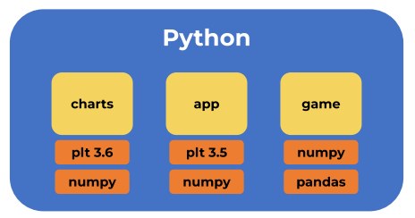

## Ejemplo

Busquemos a **matplotlib** en PIP, actualmente dice que la versión es 3.9.1.post1:

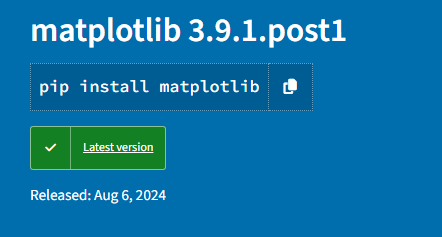

Veamos el historial de lanzamientos, podemos ver como hay más versiones y cada vez se desarrollan mas.

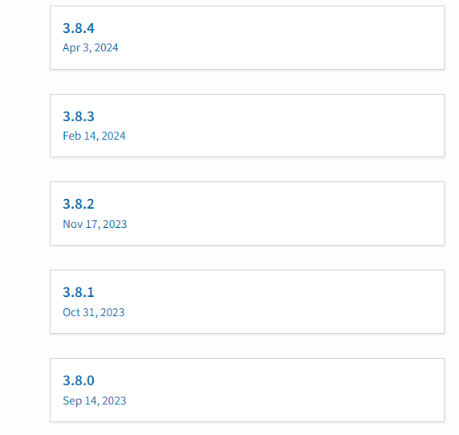

Esto puede causar algunos conflictos con ciertos proyectos, porque puede que cierto proyecto fue desarrollado con una versión especifica, pero luego otro proyecto puede estar necesitando otra versión reciente o más vieja, entonces tener el proyecto de una forma global o general, puede causar problemas.

Veamos que librerías tenemos dentro de nuestro entorno general:

```
#Ver las librerías instaladas
pip3 freeze
```

Podemos instalar otra versión de matplotlib con los siguientes comandos:

```
#Ver las librerías instaladas
pip3 install matplotlib==3.5.0
```

Nos arroja la siguiente ventana:

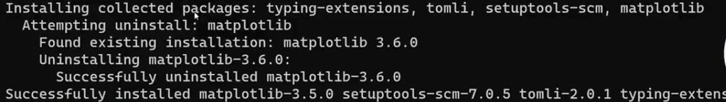

Que significa que ha desinstalado la versión que teníamos previamente, esto quiere decir que si tenemos proyectos diferentes que necesitan versiones diferentes de librerías, comenzaran a chocar y uno puede sobrescribir al otro, lo que se convierte en problemas.

En la siguiente clase vamos a ver como se soluciona esto mediante los entornos virtuales de Python, que permiten aislar los proyectos para que puedan trabajar con ciertas librerías especificas y diferentes por cada uno de ellos.